# Prediction Assignment

Prediction Assignment (autosaved)

[output not shown]

[output not shown]

```
Apply your machine learning algorithm to the 20 test cases available in the test data above and submit your predictions in appropriate format to the Course Project Prediction Quiz for automated grading.
```

```
Data:
```

```
The training data for this project are available here:
```

```
https://d396qusza40orc.cloudfront.net/predmachlearn/pml-training.csv
```

```
The test data are available here:
```

```
https://d396qusza40orc.cloudfront.net/predmachlearn/pml-testing.csv
```

```
The data for this project come from this source: http://groupware.les.inf.puc-rio.br/har.
```

## Title: 'Prediction Assignment'

### author: "Mohammad Ali Farajian"

Apply your machine learning algorithm to the 20 test cases available in the test data above and submit your predictions in appropriate format to the Course Project Prediction Quiz for automated grading.

Data:

The training data for this project are available here:

https://d396qusza40orc.cloudfront.net/predmachlearn/pml-training.csv

The test data are available here:

https://d396qusza40orc.cloudfront.net/predmachlearn/pml-testing.csv

The data for this project come from this source: http://groupware.les.inf.puc-rio.br/har.

[output not shown]

[output not shown]

[output not shown]

```
Packages, Libraries, Seed
```

```
Installing packages, loading libraries, and setting the seed for reproduceability:
```

### Code and Results

Packages, Libraries, Seed

Installing packages, loading libraries, and setting the seed for reproduceability:

```
#install.packages("caret"), install.packages("randomForest"),install.packages("lattice")
```

```
#install.packages("rpart"), install.packages("rpart.plot")
```

```
library(caret)
```

```
library(randomForest) #Random forest for classification and regression
```

```
library(rpart) # Regressive Partitioning and Regression trees
```

```
library(rpart.plot) # Decision Tree plot
```

```
# setting the overall seed for reproduceability
```

```
set.seed(1000)
```

[output not shown]

[output not shown]

[output not shown]

```
First we want to load the data sets into R and make sure that missing values are coded correctly.
```

```
Irrelevant variables will be deleted.
```

[output not shown]

## Loading data sets and preliminary cleaning

```
# After saving both data sets into my working directory
```

```
# Some missing values are coded as string "#DIV/0!" or "" or "NA" - these will be changed to NA.
```

```
# We notice that both data sets contain columns with all missing values - these will be deleted.
```

```
# Loading the training data set into my R session replacing all missing with "NA"
```

```
trainingset <- read.csv("pml-training.csv", na.strings=c("NA","#DIV/0!", ""))
```

```
# Loading the testing data set
```

```
testingset <- read.csv("pml-testing.csv", na.strings=c("NA","#DIV/0!", ""))
```

```
# Check dimensions for number of variables and number of observations
```

```
dim(trainingset)
```

```
dim(testingset)
```

1. 19622

2. 160

1. 20

2. 160

```
# Delete columns with all missing values
```

```
trainingset<-trainingset[,colSums(is.na(trainingset)) == 0]
```

```
testingset <-testingset[,colSums(is.na(testingset)) == 0]
```

```
# Some variables are irrelevant to our current project: user_name, raw_timestamp_part_1, raw_timestamp_part_,2 cvtd_timestamp, new_window, and  num_window (columns 1 to 7). We can delete these variables.
```

```
trainingset   <-trainingset[,-c(1:7)]
```

```
testingset <-testingset[,-c(1:7)]
```

```
# and have a look at our new datasets:
```

```
dim(trainingset)
```

```
head(trainingset)
```

```
dim(testingset)
```

```
head(testingset)
```

1. 19622

2. 53

| roll_belt | pitch_belt | yaw_belt | total_accel_belt | gyros_belt_x | gyros_belt_y | gyros_belt_z | accel_belt_x | accel_belt_y | accel_belt_z | ⋯ | gyros_forearm_x | gyros_forearm_y | gyros_forearm_z | accel_forearm_x | accel_forearm_y | accel_forearm_z | magnet_forearm_x | magnet_forearm_y | magnet_forearm_z | classe |
| --- | --- | --- | --- | --- | --- | --- | --- | --- | --- | --- | --- | --- | --- | --- | --- | --- | --- | --- | --- | --- |
| 1.41 | 8.07 | -94.4 | 3 | 0.00 | 0.00 | -0.02 | -21 | 4 | 22 |  | 0.03 | 0.00 | -0.02 | 192 | 203 | -215 | -17 | 654 | 476 | A |
| 1.41 | 8.07 | -94.4 | 3 | 0.02 | 0.00 | -0.02 | -22 | 4 | 22 |  | 0.02 | 0.00 | -0.02 | 192 | 203 | -216 | -18 | 661 | 473 | A |
| 1.42 | 8.07 | -94.4 | 3 | 0.00 | 0.00 | -0.02 | -20 | 5 | 23 |  | 0.03 | -0.02 | 0.00 | 196 | 204 | -213 | -18 | 658 | 469 | A |
| 1.48 | 8.05 | -94.4 | 3 | 0.02 | 0.00 | -0.03 | -22 | 3 | 21 |  | 0.02 | -0.02 | 0.00 | 189 | 206 | -214 | -16 | 658 | 469 | A |
| 1.48 | 8.07 | -94.4 | 3 | 0.02 | 0.02 | -0.02 | -21 | 2 | 24 |  | 0.02 | 0.00 | -0.02 | 189 | 206 | -214 | -17 | 655 | 473 | A |
| 1.45 | 8.06 | -94.4 | 3 | 0.02 | 0.00 | -0.02 | -21 | 4 | 21 |  | 0.02 | -0.02 | -0.03 | 193 | 203 | -215 | -9 | 660 | 478 | A |

1. 20

2. 53

| roll_belt | pitch_belt | yaw_belt | total_accel_belt | gyros_belt_x | gyros_belt_y | gyros_belt_z | accel_belt_x | accel_belt_y | accel_belt_z | ⋯ | gyros_forearm_x | gyros_forearm_y | gyros_forearm_z | accel_forearm_x | accel_forearm_y | accel_forearm_z | magnet_forearm_x | magnet_forearm_y | magnet_forearm_z | problem_id |
| --- | --- | --- | --- | --- | --- | --- | --- | --- | --- | --- | --- | --- | --- | --- | --- | --- | --- | --- | --- | --- |
| 123.00 | 27.00 | -4.75 | 20 | -0.50 | -0.02 | -0.46 | -38 | 69 | -179 |  | 0.74 | -3.34 | -0.59 | -110 | 267 | -149 | -714 | 419 | 617 | 1 |
| 1.02 | 4.87 | -88.90 | 4 | -0.06 | -0.02 | -0.07 | -13 | 11 | 39 |  | 1.12 | -2.78 | -0.18 | 212 | 297 | -118 | -237 | 791 | 873 | 2 |
| 0.87 | 1.82 | -88.50 | 5 | 0.05 | 0.02 | 0.03 | 1 | -1 | 49 |  | 0.18 | -0.79 | 0.28 | 154 | 271 | -129 | -51 | 698 | 783 | 3 |
| 125.00 | -41.60 | 162.00 | 17 | 0.11 | 0.11 | -0.16 | 46 | 45 | -156 |  | 1.38 | 0.69 | 1.80 | -92 | 406 | -39 | -233 | 783 | 521 | 4 |
| 1.35 | 3.33 | -88.60 | 3 | 0.03 | 0.02 | 0.00 | -8 | 4 | 27 |  | -0.75 | 3.10 | 0.80 | 131 | -93 | 172 | 375 | -787 | 91 | 5 |
| -5.92 | 1.59 | -87.70 | 4 | 0.10 | 0.05 | -0.13 | -11 | -16 | 38 |  | -0.88 | 4.26 | 1.35 | 230 | 322 | -144 | -300 | 800 | 884 | 6 |

[output not shown]

[output not shown]

[output not shown]

```
In order to perform cross-validation, the training data set is partionned into 2 sets: subTraining (70%) and subTest (30%).
```

```
This will be performed using random subsampling without replacement.
```

# Partitioning the training data set to allow cross-validation

In order to perform cross-validation, the training data set is partionned into 2 sets: subTraining (70%) and subTest (30%). This will be performed using random subsampling without replacement.

```
traintrainset <- createDataPartition(y=trainingset$classe, p=0.70, list=FALSE)
```

```
TrainTrainingSet <- trainingset[traintrainset, ]
```

```
TestTrainingSet <- trainingset[-traintrainset, ]
```

```
dim(TrainTrainingSet)
```

```
head(TrainTrainingSet)
```

```
dim(TestTrainingSet)
```

```
head(TestTrainingSet)
```

1. 13737

2. 53

|  | roll_belt | pitch_belt | yaw_belt | total_accel_belt | gyros_belt_x | gyros_belt_y | gyros_belt_z | accel_belt_x | accel_belt_y | accel_belt_z | ⋯ | gyros_forearm_x | gyros_forearm_y | gyros_forearm_z | accel_forearm_x | accel_forearm_y | accel_forearm_z | magnet_forearm_x | magnet_forearm_y | magnet_forearm_z | classe |
| --- | --- | --- | --- | --- | --- | --- | --- | --- | --- | --- | --- | --- | --- | --- | --- | --- | --- | --- | --- | --- | --- |
| 2 | 1.41 | 8.07 | -94.4 | 3 | 0.02 | 0.00 | -0.02 | -22 | 4 | 22 |  | 0.02 | 0.00 | -0.02 | 192 | 203 | -216 | -18 | 661 | 473 | A |
| 3 | 1.42 | 8.07 | -94.4 | 3 | 0.00 | 0.00 | -0.02 | -20 | 5 | 23 |  | 0.03 | -0.02 | 0.00 | 196 | 204 | -213 | -18 | 658 | 469 | A |
| 4 | 1.48 | 8.05 | -94.4 | 3 | 0.02 | 0.00 | -0.03 | -22 | 3 | 21 |  | 0.02 | -0.02 | 0.00 | 189 | 206 | -214 | -16 | 658 | 469 | A |
| 5 | 1.48 | 8.07 | -94.4 | 3 | 0.02 | 0.02 | -0.02 | -21 | 2 | 24 |  | 0.02 | 0.00 | -0.02 | 189 | 206 | -214 | -17 | 655 | 473 | A |
| 6 | 1.45 | 8.06 | -94.4 | 3 | 0.02 | 0.00 | -0.02 | -21 | 4 | 21 |  | 0.02 | -0.02 | -0.03 | 193 | 203 | -215 | -9 | 660 | 478 | A |
| 7 | 1.42 | 8.09 | -94.4 | 3 | 0.02 | 0.00 | -0.02 | -22 | 3 | 21 |  | 0.02 | 0.00 | -0.02 | 195 | 205 | -215 | -18 | 659 | 470 | A |

1. 5885

2. 53

|  | roll_belt | pitch_belt | yaw_belt | total_accel_belt | gyros_belt_x | gyros_belt_y | gyros_belt_z | accel_belt_x | accel_belt_y | accel_belt_z | ⋯ | gyros_forearm_x | gyros_forearm_y | gyros_forearm_z | accel_forearm_x | accel_forearm_y | accel_forearm_z | magnet_forearm_x | magnet_forearm_y | magnet_forearm_z | classe |
| --- | --- | --- | --- | --- | --- | --- | --- | --- | --- | --- | --- | --- | --- | --- | --- | --- | --- | --- | --- | --- | --- |
| 1 | 1.41 | 8.07 | -94.4 | 3 | 0.00 | 0.00 | -0.02 | -21 | 4 | 22 |  | 0.03 | 0.00 | -0.02 | 192 | 203 | -215 | -17 | 654 | 476 | A |
| 10 | 1.45 | 8.17 | -94.4 | 3 | 0.03 | 0.00 | 0.00 | -21 | 4 | 22 |  | 0.02 | 0.00 | -0.02 | 190 | 205 | -215 | -22 | 656 | 473 | A |
| 12 | 1.43 | 8.18 | -94.4 | 3 | 0.02 | 0.00 | -0.02 | -22 | 2 | 23 |  | 0.02 | 0.02 | -0.03 | 191 | 203 | -215 | -11 | 657 | 478 | A |
| 13 | 1.42 | 8.20 | -94.4 | 3 | 0.02 | 0.00 | 0.00 | -22 | 4 | 21 |  | 0.00 | 0.00 | -0.03 | 193 | 205 | -215 | -15 | 655 | 472 | A |
| 22 | 1.57 | 8.09 | -94.4 | 3 | 0.02 | 0.02 | -0.02 | -21 | 3 | 21 |  | 0.02 | -0.03 | -0.02 | 191 | 206 | -213 | -17 | 654 | 478 | A |
| 23 | 1.56 | 8.10 | -94.3 | 3 | 0.02 | 0.00 | -0.02 | -21 | 4 | 21 |  | 0.02 | -0.02 | -0.02 | 194 | 206 | -214 | -10 | 653 | 467 | A |

[output not shown]

```
The variable “classe” contains 5 levels: A, B, C, D and E. A plot of the outcome variable will allow us to see the frequency of each levels in the TrainTrainingSet  data set and compare one another.
```

## A look at the Data

The variable “classe” contains 5 levels: A, B, C, D and E. A plot of the outcome variable will allow us to see the frequency of each levels in the TrainTrainingSet data set and compare one another.

```
plot(TrainTrainingSet$classe, col="green", main="Barchart of levels of variable classe within the TrainTrainingSet data set", xlab="classe Level", ylab="Frequency")
```

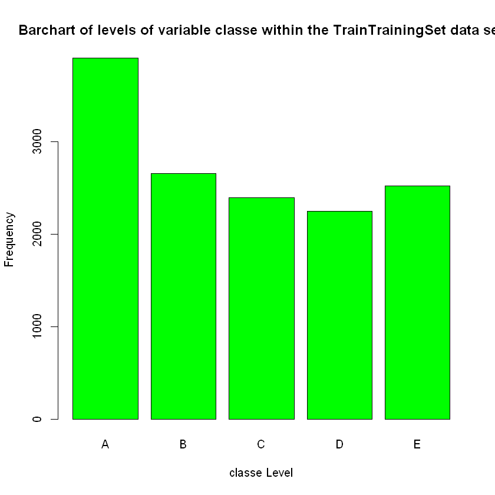

```
Based on the graph above, we can see that each level frequency is within the same order of magnitude of each other. Level A is the most frequent while level D is the least frequent with about 2200 occurrences.
```

[output not shown]

[output not shown]

Based on the graph above, we can see that each level frequency is within the same order of magnitude of each other. Level A is the most frequent while level D is the least frequent with about 2200 occurrences.

## First prediction model: Using Decision Tree

```
model1 <- rpart(classe ~ ., data=TrainTrainingSet, method="class")
```

```
prediction1 <- predict(model1, TestTrainingSet, type = "class")
```

```
# Plot the Decision Tree
```

```
rpart.plot(model1, main="Classification Tree", extra=102, under=TRUE, faclen=0)
```

[figure not shown]

```
# Test results on our TestTrainingSet data set:
```

```
confusionMatrix(prediction1, TestTrainingSet$classe)
```

```
Confusion Matrix and Statistics

          Reference
Prediction    A    B    C    D    E
         A 1461  150   10   57   50
         B   88  814  138   68   71
         C   14  111  790  161   83
         D   44   56   47  643   82
         E   67    8   41   35  796

Overall Statistics

               Accuracy : 0.7653
                 95% CI : (0.7543, 0.7761)
    No Information Rate : 0.2845
    P-Value [Acc > NIR] : < 2.2e-16

                  Kappa : 0.7028

 Mcnemar's Test P-Value : < 2.2e-16

Statistics by Class:

                     Class: A Class: B Class: C Class: D Class: E
Sensitivity            0.8728   0.7147   0.7700   0.6670   0.7357
Specificity            0.9366   0.9231   0.9241   0.9535   0.9686
Pos Pred Value         0.8455   0.6904   0.6816   0.7374   0.8405
Neg Pred Value         0.9488   0.9309   0.9501   0.9360   0.9421
Prevalence             0.2845   0.1935   0.1743   0.1638   0.1839
Detection Rate         0.2483   0.1383   0.1342   0.1093   0.1353
Detection Prevalence   0.2936   0.2003   0.1969   0.1482   0.1609
Balanced Accuracy      0.9047   0.8189   0.8470   0.8102   0.8521
```

[output not shown]

[output not shown]

## Second prediction model: Using Random Forest

```
model2 <- randomForest(classe ~. , data=TrainTrainingSet, method="class")
```

```
# Predicting:
```

```
prediction2 <- predict(model2, TestTrainingSet, type = "class")
```

```
# Test results on TestTrainingSet data set:
```

```
confusionMatrix(prediction2, TestTrainingSet$classe)
```

```
Confusion Matrix and Statistics

          Reference
Prediction    A    B    C    D    E
         A 1671    6    0    0    0
         B    3 1132    6    0    0
         C    0    1 1018   11    0
         D    0    0    2  952    3
         E    0    0    0    1 1079

Overall Statistics

               Accuracy : 0.9944
                 95% CI : (0.9921, 0.9961)
    No Information Rate : 0.2845
    P-Value [Acc > NIR] : < 2.2e-16

                  Kappa : 0.9929

 Mcnemar's Test P-Value : NA

Statistics by Class:

                     Class: A Class: B Class: C Class: D Class: E
Sensitivity            0.9982   0.9939   0.9922   0.9876   0.9972
Specificity            0.9986   0.9981   0.9975   0.9990   0.9998
Pos Pred Value         0.9964   0.9921   0.9883   0.9948   0.9991
Neg Pred Value         0.9993   0.9985   0.9984   0.9976   0.9994
Prevalence             0.2845   0.1935   0.1743   0.1638   0.1839
Detection Rate         0.2839   0.1924   0.1730   0.1618   0.1833
Detection Prevalence   0.2850   0.1939   0.1750   0.1626   0.1835
Balanced Accuracy      0.9984   0.9960   0.9949   0.9933   0.9985
```

[output not shown]

```
Random Forest algorithm performed better than Decision Trees. Accuracy for Random Forest model was 0.9944  (95% CI : (0.9921, 0.9961)) compared to Decision Tree model with Accuracy : 0.7653
```

```
(95% CI : (0.7543, 0.7761)) . The Random Forests model is choosen. The expected out-of-sample error is estimated at 0.0056, or 0.56%.
```

## Decision on which Prediction Model to Use:

Random Forest algorithm performed better than Decision Trees. Accuracy for Random Forest model was 0.9944 (95% CI : (0.9921, 0.9961)) compared to Decision Tree model with Accuracy : 0.7653  
(95% CI : (0.7543, 0.7761)) . The Random Forests model is choosen. The expected out-of-sample error is estimated at 0.0056, or 0.56%.

[output not shown]

```
Here is the final outcome based on the Prediction Model Random Forest applied against the Testing dataset
```

## Submission

Here is the final outcome based on the Prediction Model Random Forest applied against the Testing dataset

```
# predict outcome levels on the original Testing data set using Random Forest algorithm
```

```
predictfinal <- predict(model2, testingset, type="class")
```

```
predictfinal
```

**1**

B

**2**

A

**3**

B

**4**

A

**5**

A

**6**

E

**7**

D

**8**

B

**9**

A

**10**

A

**11**

B

**12**

C

**13**

B

**14**

A

**15**

E

**16**

E

**17**

A

**18**

B

**19**

B

**20**

B

**Levels**:**

1. 'A'

2. 'B'

3. 'C'

4. 'D'

5. 'E'